# Text-analysis of Dune, by Frank Herbert

Renee LaManna

3/6/2022

## Overview

This text-analysis explores common words and sentiments in the sci-fi novel *Dune* by Frank Herbert. The PDF of *Dune* is converted into data frame and wrangled to divide the novel into it’s three books: Dune, Muad’Dib, and The Prophet. The most common sentiments and words in each of the three books is then visually compared. The text of the novel was obtained from github user ganesh-k13.

**Citation:** Herbert, Frank. (1965). *Dune*. https://raw.githubusercontent.com/ganesh-k13/shell/master/test_search/www.glozman.com/TextPages/Frank%20Herbert%20-%20Dune.txt

```r
knitr::opts_chunk$set(echo = TRUE, message=FALSE, warning=FALSE)
# Set code chunk options and attatch necessary pkgs

library(tidyverse)
library(tidytext)
library(textdata)
library(pdftools)
library(ggwordcloud)
library(patchwork)
```

```r
# Read in the data and store as dune_text
dune_text <- pdf_text(here::here('data', 'dune.pdf'))
```

```r
# Convert text into dataframe

dune_lines <- data.frame(dune_text) %>%
  mutate(page = 1:n()) %>%
  mutate(text_full = str_split(dune_text, pattern = '\\n')) %>%
  unnest(text_full) %>%
  mutate(text_full = str_trim(text_full))
```

```r
# Make new column that contains book number

dune_books <- dune_lines %>%
  slice(-(398:429)) %>% # remove appendices
  slice(-(1:5)) %>% # remove first couple words before Book 1 begins
  mutate(book = ifelse((text_full %in% c("Book 1", "Book Two", "Book Three")), text_full, NA)) %>% # in text_full, look for the following, "Book 1", "Book Two", & "Book Three", make everything else NA
  fill(book, .direction = "down") %>%
  separate(col = book, into = c("book", "no"), sep = " ") %>%
  mutate(no = case_when(
    no == "1" ~ "1: Dune",
    no == "Two" ~ "2: Muad'Dib",
    no == "Three" ~ "3: The Prophet"
  ))
```

```r
# Get word counts by book

dune_words <- dune_books %>%
  unnest_tokens(word, text_full) %>%
  select(-dune_text)
```

```r
# Remove stopwords

head(stop_words)
x <- stop_words

dune_words_clean <- dune_words %>%
  anti_join(stop_words, by = "word")

nonstop_counts <- dune_words_clean %>%
  count(no,word)
```

## I. Most Frequent Words

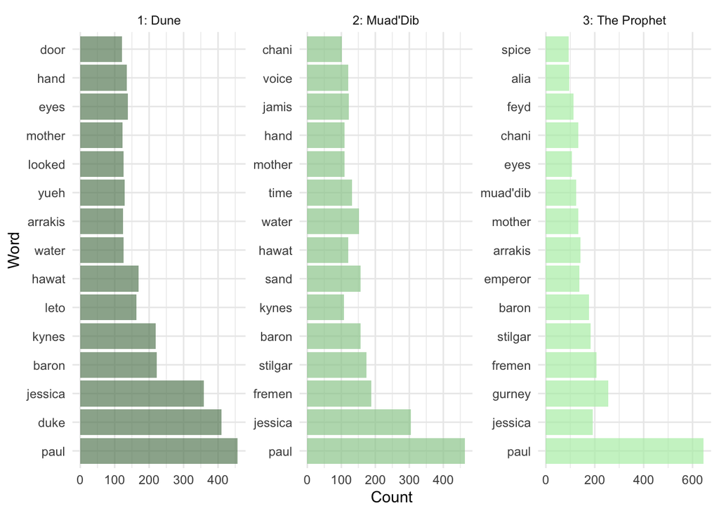

```r
# Get top 15 words from nonstop_counts
top_15_words <- nonstop_counts %>%
  group_by(no) %>%
  arrange(-n) %>%
  slice(1:15) %>%
  ungroup() %>%
  mutate(word = fct_reorder(word, desc(n)))

# Make some graphs:
ggplot(data = top_15_words, aes(x = n, y = word)) +
  geom_col(aes(fill = no), alpha = 0.7) +
  scale_fill_manual(values = c("darkseagreen4", "darkseagreen3", "darkseagreen2")) +
  facet_wrap(~no, scales = "free") +
  theme_minimal() +
  theme(legend.position = "none") +  # remove legend
  labs(x = "Count", y = "Word")
```

**Figure 1.** Visualization of the most common words found in each of the three books within the novel, *Dune*.

## II. Sentiment Analysis: Scores

```r
# Get sentiments
dune_afinn <- dune_words_clean %>%
  inner_join(get_sentiments("afinn"), by = 'word')
```

```r
afinn_counts <- dune_afinn %>%
  count(no, value, word)

# Plot them:
p1 <- ggplot(data = afinn_counts, aes(x = value, y = n)) +
  geom_col(aes(fill = no), alpha = 0.7) +
  scale_fill_manual(values = c("darkseagreen4", "darkseagreen3", "darkseagreen2")) +
  facet_wrap(~no) +
  theme_minimal() +
  theme(legend.position = "none") +
  labs(title = "A", x = "Score", y = "Count")
```

```r
# Find the mean afinn score by chapter:
afinn_means <- dune_afinn %>%
  group_by(no) %>%  # group_by book #
  summarize(mean_afinn = mean(value))

# Plot afinn_means and store as p2
p2 <- ggplot(data = afinn_means,
       aes(x = fct_rev(factor(no)),
           y = mean_afinn)) +
           # y = fct_rev(as.factor(no))) +
  geom_col(aes(fill = no), alpha = 0.7) +
  scale_fill_manual(values = c("darkseagreen4", "darkseagreen3", "darkseagreen2"))  +
  coord_flip() +
  theme_minimal() +
  theme(legend.position = "none") +
  labs(title = "B", y = "Score", x = "Book #")
```

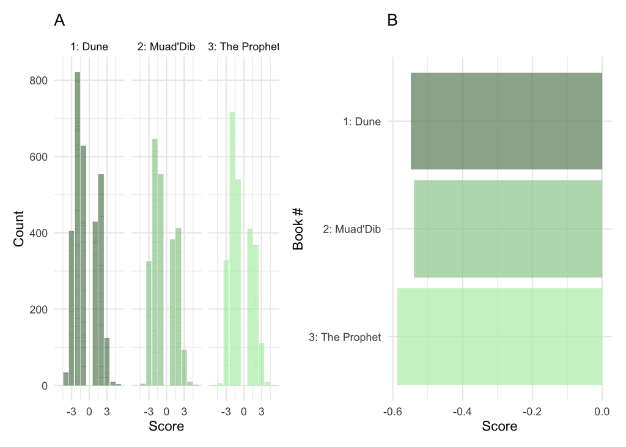

```r
# Combine p1 and p2 using patchwork pkg
p1 + p2
```

**Figure 2.** Sentiment analysis exploring positive and negative sentiments between the three books within the novel, *Dune*. A more negative score indicates a more negative sentiment, while a more positive value indicates a more positive sentiment. Figure A. shows the distribution of positive and negative sentiments among the three books. Figure B. shows the average score in each of the three books.

## III. Sentiment Analysis: Word Clouds

```r
# Get sentiments and joing by "word"
dune_nrc <- dune_words_clean %>%
  inner_join(get_sentiments("nrc"))
```

### Book 1: “Dune”

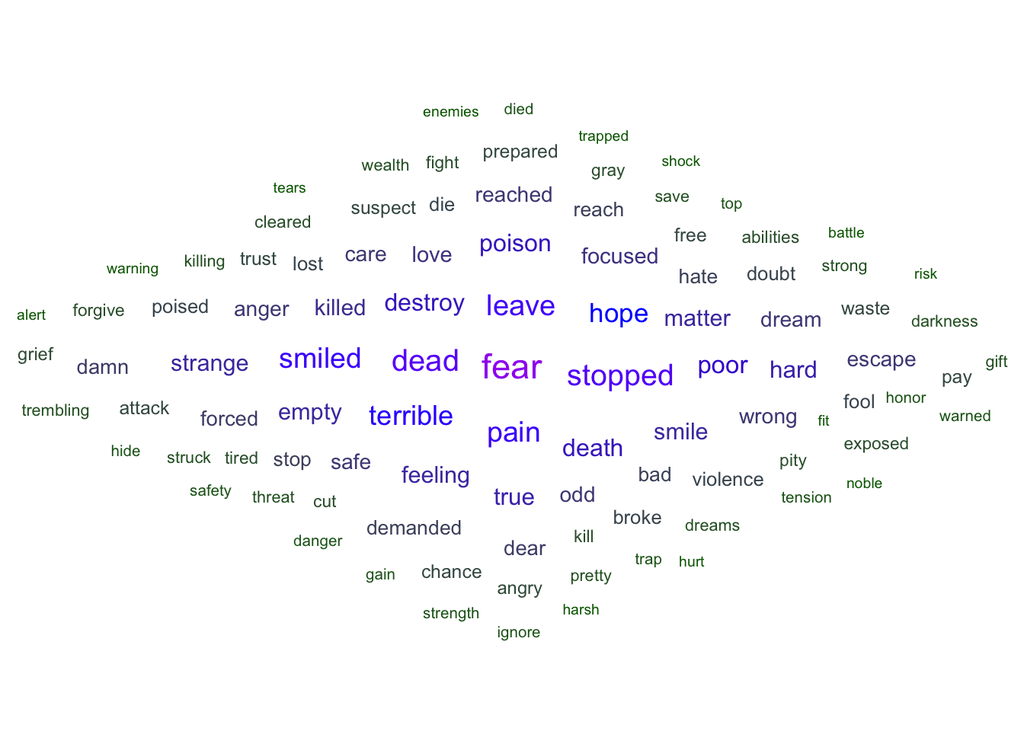

```r
# Get top 10 sentiments from Book 1 and make wordcloud
book1_top100 <- afinn_counts %>%
  filter(no == "1: Dune") %>%
  arrange(-n) %>%
  slice(1:100)

book1_cloud <- ggplot(data = book1_top100, aes(label = word)) +
  geom_text_wordcloud(aes(color = n, size = n), shape = "diamond") +
  scale_size_area(max_size = 6) +
  scale_color_gradientn(colors = c("darkgreen","blue","purple")) +
  theme_minimal()

book1_cloud
```

**Figure 3.** Word cloud of common sentiments in Book 1: “Dune”. Larger and more centered words are more common sentiments and smaller words further from the center are less common sentiments.

### Book 2: “Muad’Dib”

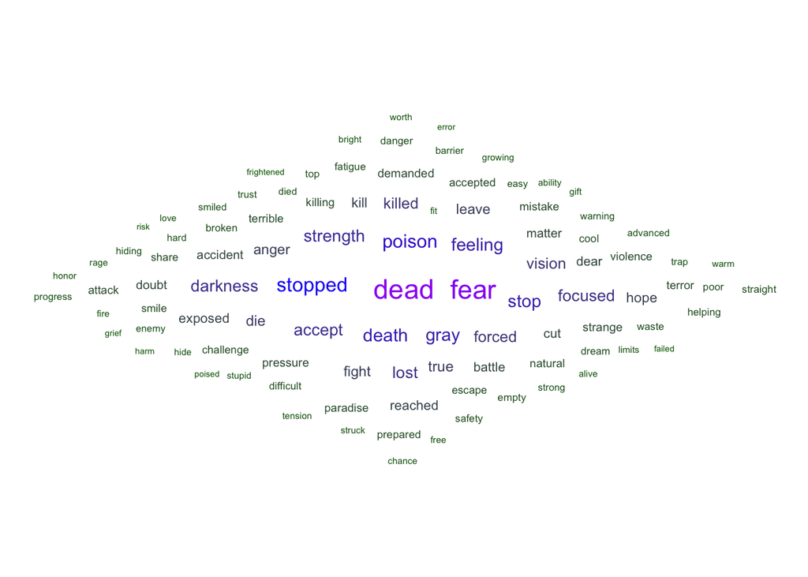

```r
# Get top 10 sentiments from Book 2 and make wordcloud
book2_top100 <- afinn_counts %>%
  filter(no == "2: Muad'Dib") %>%
  arrange(-n) %>%
  slice(1:100)

book2_cloud <- ggplot(data = book2_top100, aes(label = word)) +
  geom_text_wordcloud(aes(color = n, size = n), shape = "diamond") +
  scale_size_area(max_size = 6) +
  scale_color_gradientn(colors = c("darkgreen","blue","purple")) +
  theme_minimal()

book2_cloud
```

**Figure 4.** Word cloud of common sentiments in Book 2: “Muad’Dib”. Larger and more centered words are more common sentiments and smaller words further from the center are less common sentiments.

### Book 3: “The Prophet”

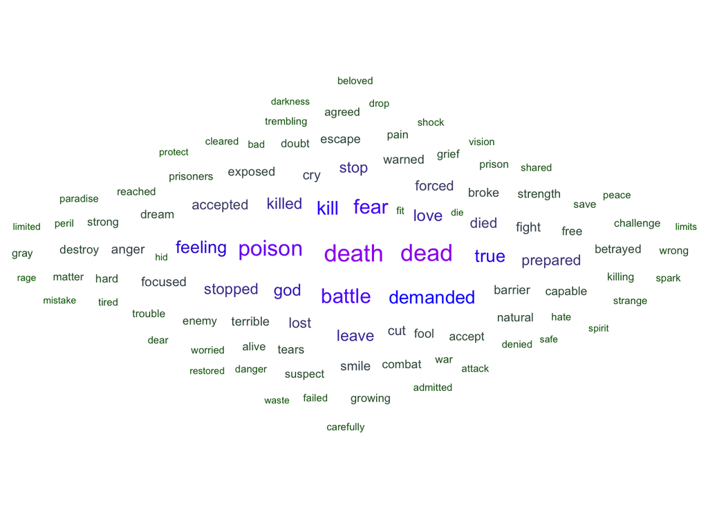

```r
# Get top 10 sentiments from Book 3 and make wordcloud
book3_top100 <- afinn_counts %>%
  filter(no == "3: The Prophet") %>%
  arrange(-n) %>%
  slice(1:100)

book3_cloud <- ggplot(data = book3_top100, aes(label = word)) +
  geom_text_wordcloud(aes(color = n, size = n), shape = "diamond") +
  scale_size_area(max_size = 6) +
  scale_color_gradientn(colors = c("darkgreen","blue","purple")) +
  theme_minimal()

book3_cloud
```

**Figure 5.** Word cloud of common sentiments in Book 3: “The Prophet”. Larger and more centered words are more common sentiments and smaller words further from the center are less common sentiments.

## Main Takeaways

- Most common words are character names. We can see some transition and introduction of characters between books such as the introduction of Chani in Book 2 and Alia in Book 3.
- In all three of the books within the novel *Dune*, the mean sentiment is negative, with the greatest negative mean being in the final book.
- The trend of negative sentiments can be visualized in the word clouds with death/dead being some of the more common sentiments throughout the books.
- In future analysis, it may be more revealing to remove common character names from the top 15 words. It also would be interesting to look at sentiments within just one of the books and between chapters
- Overall not much variation in sentiment between each of the books within *Dune*